# ITMO_appl_stat_HW3_Balan

2024-15-09

```r
library(readxl)
library(ggplot2)
library(ggforce)
library(plotly)
library(impute)
library(factoextra)
library(psych)
library(vegan)
library(rstatix)

theme_set(theme_bw())
```

```r
data <- read_excel('Sleepy lizard.xlsx')
data <- select(data, Treatment, Habitat, Connectivity, Tot_WBC, Het_ABS,
               Lym_ABS, `H:L Ratio`, Mon_ABS, OthG_ABS, LBSI) #The list of features from HW task
```

## Changing some features to factors

```r
data$Treatment <-  as.factor(data$Treatment)
data$Habitat <- as.factor(data$Habitat)
data$Connectivity <-  as.factor(data$Connectivity)
```

# EDA

```r
describe(data)
```

```
##               vars   n    mean      sd  median trimmed     mad     min     max
## Treatment*       1 122    1.75    0.43    2.00    1.82    0.00    1.00     2.0
## Habitat*         2 122    1.73    0.84    1.00    1.66    0.00    1.00     3.0
## Connectivity*    3 122    2.63    1.19    3.00    2.66    1.48    1.00     4.0
## Tot_WBC          4 122 6964.04 8041.71 4880.38 5446.49 2293.66 1714.29 74667.0
## Het_ABS          5 122 3804.92 5552.60 2400.00 2822.45 1186.08 1200.00 56000.0
## Lym_ABS          6 122 1489.17 1217.72 1248.00 1289.72  570.82  257.00 10971.0
## H:L Ratio        7 122    2.90    3.07    1.92    2.23    0.93    0.82    25.0
## Mon_ABS          8 122  487.51  507.01  303.36  396.94  277.84    0.00  3135.0
## OthG_ABS         9 122  829.88 1644.35  153.52  429.81  166.79    0.00 10453.0
## LBSI            10 122    0.00    0.05    0.00    0.00    0.05   -0.14     0.1
##                  range  skew kurtosis     se
## Treatment*        1.00 -1.17    -0.65   0.04
## Habitat*          2.00  0.54    -1.40   0.08
## Connectivity*     3.00 -0.12    -1.52   0.11
## Tot_WBC       72952.71  5.62    40.73 728.06
## Het_ABS       54800.00  7.14    61.81 502.71
## Lym_ABS       10714.00  4.59    29.55 110.25
## H:L Ratio        24.18  4.14    22.31   0.28
## Mon_ABS        3135.00  2.19     6.35  45.90
## OthG_ABS      10453.00  3.02    10.78 148.87
## LBSI              0.24 -0.38     0.14   0.00
```

```r
data_blood <- select(data, -Treatment, -Habitat, -Connectivity)
```

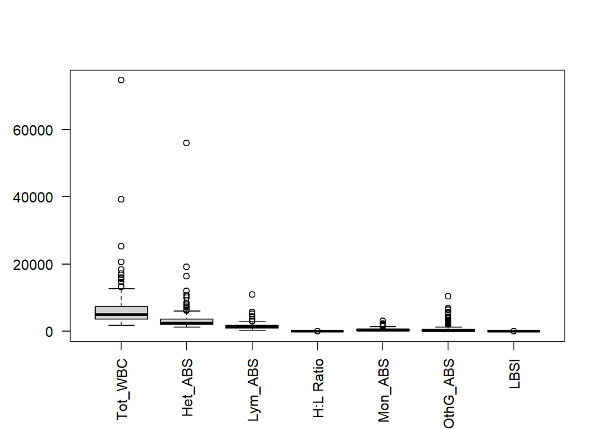

```r
boxplot(data_blood, las=2) #needs to be normalized
```

## Normalization

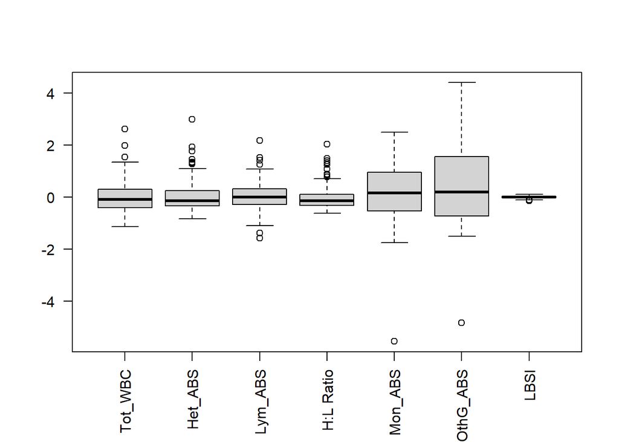

```r
data_blood_lognorm <- scale(log(data_blood+1), scale = FALSE)
boxplot(data_blood_lognorm, las=2)
```

# PCA

```r
pca_data <- prcomp(data_blood_lognorm)$x %>%
  as.data.frame() %>%
  select(PC1, PC2)

pca_data$Treatment = data$Treatment
pca_data$Habitat = data$Habitat
```

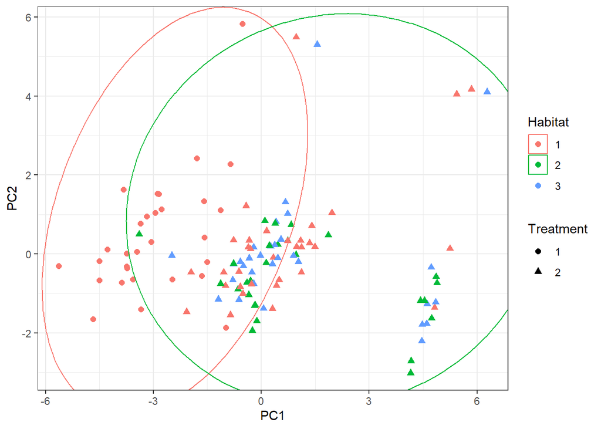

```r
ggplot(pca_data, aes(x=PC1, y=PC2, shape=Treatment, col=Habitat))+
  geom_point(size=2)+
  geom_mark_ellipse(aes(col = Treatment))
```

We can see that clusters are disttinguishable from each other, maybe this difference is significant

# perMANOVA

## Choosing suitable dissimilarity index

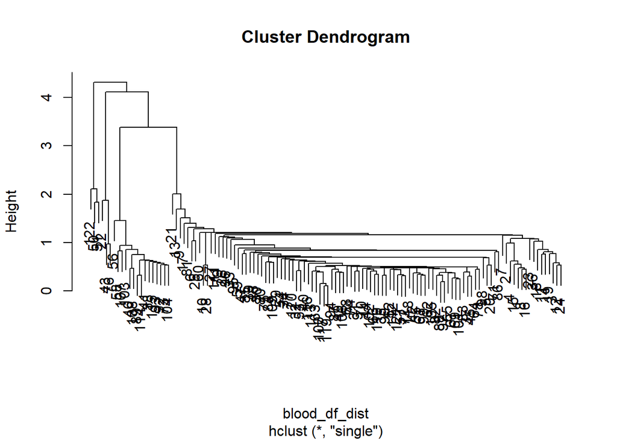

```r
blood_df_dist <- vegdist(data_blood_lognorm, method  = "euclidean")
hc_single <- hclust(blood_df_dist, method = 'single')
plot(hc_single)
```

The Canberra distance has been used as a metric for comparing ranked lists[3] and for intrusion detection in computer security.[4] It has also been used to analyze the gut microbiome in different disease states. (wiki)

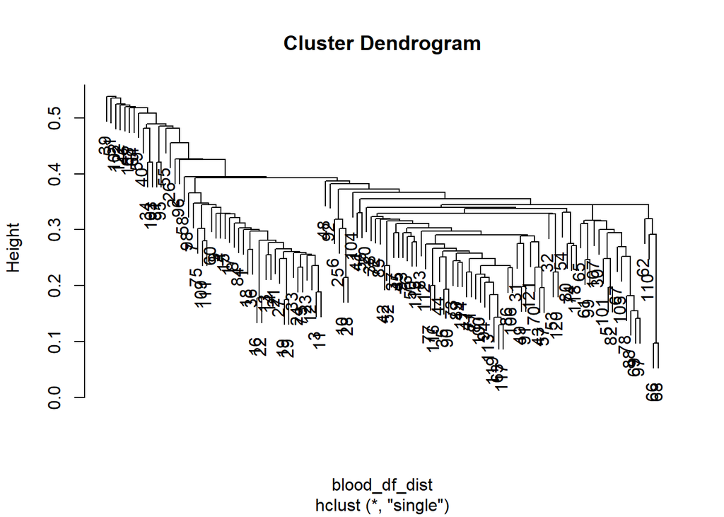

```r
blood_df_dist <- vegdist(data_blood_lognorm, method  = "canberra")
hc_single <- hclust(blood_df_dist, method = 'single')
plot(hc_single)
```

the Bray-Curtis dissimilarity is a statistic used to quantify the dissimilarity in species composition between two different sites, based on counts at each site.(wiki)

```r
blood_df_dist <- vegdist(data_blood_lognorm, method  = "bray")
```

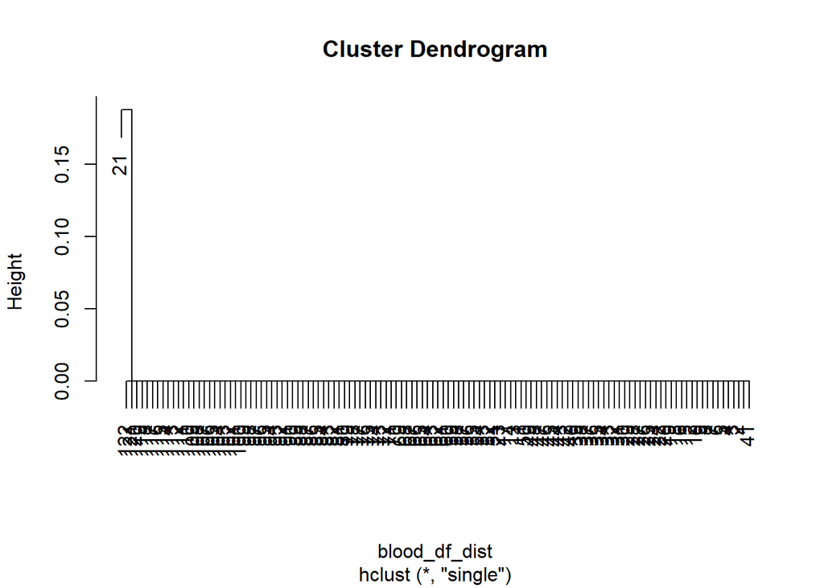

```r
hc_single <- hclust(blood_df_dist, method = 'single')
plot(hc_single)
```

Seems like euclidean and canberra distances are pretty fine to use

## Check applicability of analysis

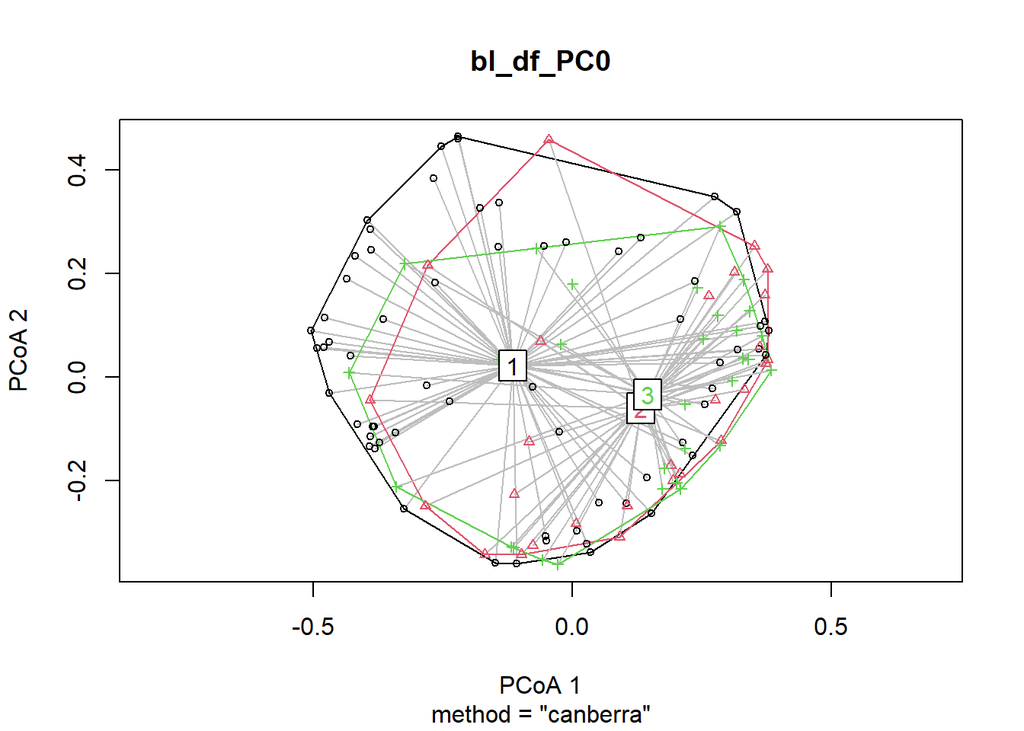

```r
blood_df_dist <- vegdist(data_blood_lognorm, method  = "canberra")
bl_df_PC0 <- betadisper(blood_df_dist, data$Habitat)
plot(bl_df_PC0)
```

```r
anova(bl_df_PC0)
```

```
## Analysis of Variance Table
##
## Response: Distances
##            Df  Sum Sq   Mean Sq F value  Pr(>F)
## Groups      2 0.03602 0.0180086  2.8832 0.05988 .
## Residuals 119 0.74329 0.0062461
## ---
## Signif. codes:  0 '***' 0.001 '**' 0.01 '*' 0.05 '.' 0.1 ' ' 1
```

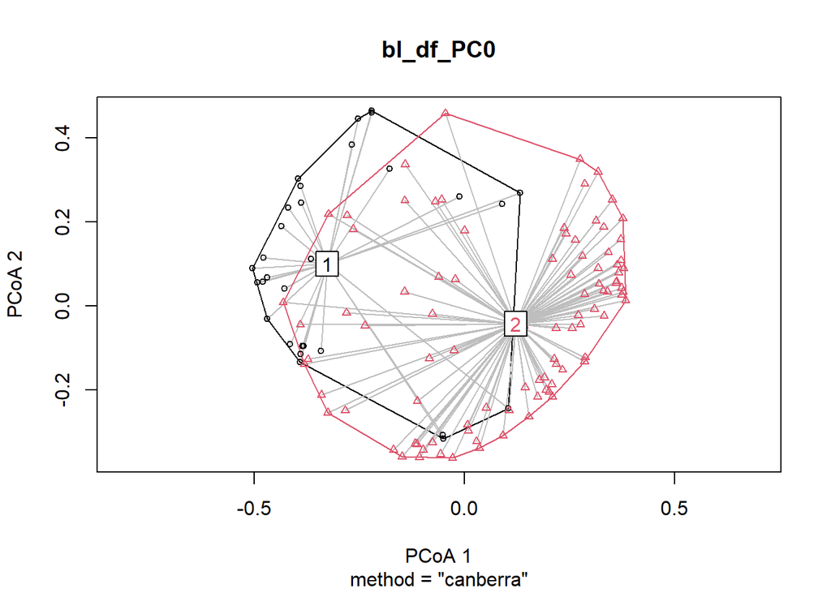

```r
blood_df_dist <- vegdist(data_blood_lognorm, method  = "canberra")
bl_df_PC0 <- betadisper(blood_df_dist, data$Treatment)
plot(bl_df_PC0)
```

```r
anova(bl_df_PC0)
```

```
## Analysis of Variance Table
##
## Response: Distances
##            Df  Sum Sq  Mean Sq F value    Pr(>F)
## Groups      1 0.10943 0.109432   11.71 0.0008508 ***
## Residuals 120 1.12144 0.009345
## ---
## Signif. codes:  0 '***' 0.001 '**' 0.01 '*' 0.05 '.' 0.1 ' ' 1
```

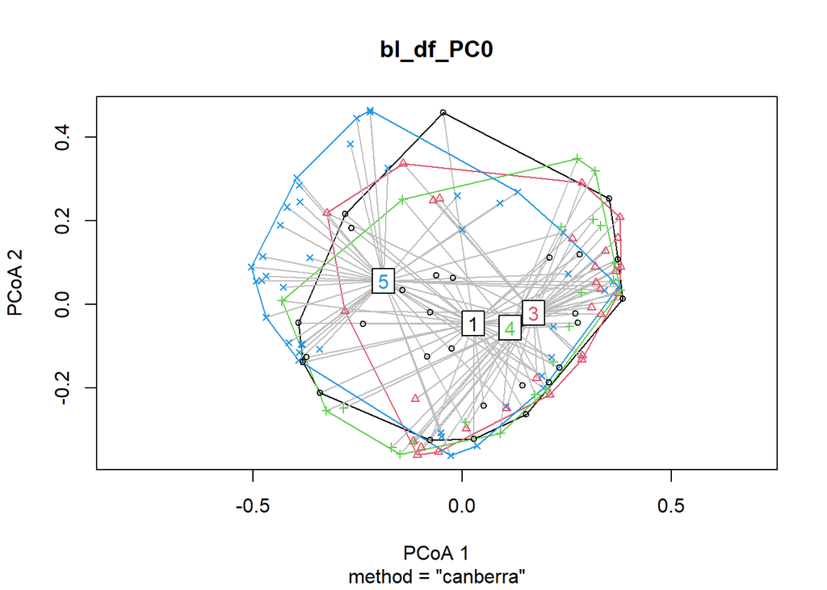

```r
blood_df_dist <- vegdist(data_blood_lognorm, method  = "canberra")
bl_df_PC0 <- betadisper(blood_df_dist, data$Connectivity)
plot(bl_df_PC0)
```

```r
anova(bl_df_PC0)
```

```
## Analysis of Variance Table
##
## Response: Distances
##            Df  Sum Sq  Mean Sq F value Pr(>F)
## Groups      3 0.03076 0.010252  1.3286 0.2684
## Residuals 118 0.91061 0.007717
```

## Task 1

#### a: Blood composition ~ Treatment

```r
adonis2(data_blood_lognorm ~ data$Treatment, method = "canberra")
```

```
## Permutation test for adonis under reduced model
## Terms added sequentially (first to last)
## Permutation: free
## Number of permutations: 999
##
## adonis2(formula = data_blood_lognorm ~ data$Treatment, method = "canberra")
##                 Df SumOfSqs      R2      F Pr(>F)
## data$Treatment   1    4.505 0.13707 19.061  0.001 ***
## Residual       120   28.364 0.86293
## Total          121   32.869 1.00000
## ---
## Signif. codes:  0 '***' 0.001 '**' 0.01 '*' 0.05 '.' 0.1 ' ' 1
```

#### b: Blood composition ~ Habitat

```r
data_sub <- data_blood_lognorm %>% as.data.frame() %>% filter(data$Treatment == 2)
habitat_sub <- subset(data, Treatment == 2)$Habitat
#OR
habitat_sub <- data[data$Treatment == 2,]$Habitat
```

```r
adonis2(data_sub ~ habitat_sub, method = "canberra")
```

```
## Permutation test for adonis under reduced model
## Terms added sequentially (first to last)
## Permutation: free
## Number of permutations: 999
##
## adonis2(formula = data_sub ~ habitat_sub, method = "canberra")
##             Df SumOfSqs     R2      F Pr(>F)
## habitat_sub  2   0.3024 0.0133 0.5999  0.891
## Residual    89  22.4300 0.9867
## Total       91  22.7324 1.0000
```

#### c: Blood composition ~ Connectivity

```r
connect_sub <- subset(data, Treatment == 2)$Connectivity
```

```r
adonis2(data_sub ~ connect_sub, method = "canberra")
```

```
## Permutation test for adonis under reduced model
## Terms added sequentially (first to last)
## Permutation: free
## Number of permutations: 999
##
## adonis2(formula = data_sub ~ connect_sub, method = "canberra")
##             Df SumOfSqs      R2      F Pr(>F)
## connect_sub  3   0.9978 0.04389 1.3466  0.142
## Residual    88  21.7346 0.95611
## Total       91  22.7324 1.00000
```

## Task 2

```r
adonis2(data_sub ~ connect_sub + habitat_sub, method = "canberra")
```

```
## Permutation test for adonis under reduced model
## Terms added sequentially (first to last)
## Permutation: free
## Number of permutations: 999
##
## adonis2(formula = data_sub ~ connect_sub + habitat_sub, method = "canberra")
##             Df SumOfSqs      R2      F Pr(>F)
## connect_sub  3   0.9978 0.04389 1.3316  0.146
## habitat_sub  2   0.2541 0.01118 0.5087  0.927
## Residual    86  21.4805 0.94493
## Total       91  22.7324 1.00000
```

## Conclusion

habitat modification has a significant impact on the blood composition of lizards. Lizards from modified landscapes have different blood composition compared to lizards from unmodified habitats, regardless of connectivity.

The PCA analysis revealed that lizards from different treatment groups are distinct from each other. However, the relatively low intra-group variability within the modified landscape group suggests that lizards from different habitat types within this group are more similar to each other than they are to lizards from unmodified habitats.